# Analisis Exploratorio

Marcela Vivas

2024-01-31

## Estadisticas descriptivas

- Recuento normal de **leucocitos** es de 4,500 a 11,000 GB por microlitro, recuento bajo de leucocitos (leucopenia) es de menos de 4,500 celulas por microlitro (https://medlineplus.gov/spanish/ency/article/003643.htm#)
- Recuento normal de **plaquetas** es de 150,000 a 400,000 plaquetas por microlitro, un conteo bajo de plaquetas (trombocitopenia) es de menos de 150,000, inferior a 50000 es grave. (https://www.nhlbi.nih.gov/es/salud/trastornos-plaquetarios/diagnostico#)
- Recuento normal de **monocitos** es de 100 a 800 microlitros (https://okdiario.com/salud/monocitos-valores-normales-2803544)
- Recuento normal de **Hematocritos** de 36 a 48% para mujeres y 42 a 52% para hombres (https://www.stanfordchildrens.org/es/topic/default?id=hematocrit-167-hematocrit_ES)
- Recuento normal de **Hemoglobina** para Hombre: de 13.8 a 17.2 gramos por decilitro (g/dL) o 138 a 172 gramos por litro (g/L) y Mujer: de 12.1 a 15.1 g/dL o 121 a 151 g/L (https://medlineplus.gov/spanish/ency/article/003645.htm)
- Recuento normal de **Linfocitos** es de 1.000 y 4.000 linfocitos en un microlitro (https://www.salud.mapfre.es/enfermedades/hematologicas/significado-leucocitos-valor-bajo-y-alto/#)
- Recuento normal de **Neutrofilos** es de 2.000 y 8.000 neutrófilos en un microlitro

Se realiza un analisis de las variables en general

```r
summary(Datos)
```

```
##     p9_Leuco      p10_Plaquetas       nmono          hemoglobin
##  Min.   : 1.100   Min.   : 29.0   Min.   :0.0100   Min.   : 7.60
##  1st Qu.: 5.532   1st Qu.:193.0   1st Qu.:0.5000   1st Qu.:12.80
##  Median : 7.185   Median :237.0   Median :0.6700   Median :13.80
##  Mean   : 8.218   Mean   :241.0   Mean   :0.7583   Mean   :13.91
##  3rd Qu.: 9.845   3rd Qu.:284.2   3rd Qu.:0.9525   3rd Qu.:15.20
##  Max.   :32.110   Max.   :668.0   Max.   :3.7900   Max.   :18.30
##   hematocrito     nlinfocitos       nneutros      hematocrito_hemoglobina
##  Min.   :22.90   Min.   :0.140   Min.   : 0.130   Min.   :2.694
##  1st Qu.:38.60   1st Qu.:1.157   1st Qu.: 3.178   1st Qu.:2.916
##  Median :41.40   Median :1.650   Median : 4.680   Median :2.993
##  Mean   :41.59   Mean   :1.870   Mean   : 5.405   Mean   :2.996
##  3rd Qu.:44.80   3rd Qu.:2.303   3rd Qu.: 6.455   3rd Qu.:3.066
##  Max.   :52.30   Max.   :9.180   Max.   :27.880   Max.   :3.421
##  linfocitos_neutrofilos DX       ...11
##  Min.   : 0.03944       0:300   Mode:logical
##  1st Qu.: 0.20901       1: 24   NA's:324
##  Median : 0.37282
##  Mean   : 0.56582
##  3rd Qu.: 0.59116
##  Max.   :29.15385
```

Se realiza un analisis de las variables divididas en enfermos y no enfermos

```r
#Enfermos
summary(enfermos)
```

```
##     p9_Leuco      p10_Plaquetas       nmono          hemoglobin
##  Min.   : 1.100   Min.   : 29.0   Min.   :0.0700   Min.   :10.30
##  1st Qu.: 4.152   1st Qu.: 65.5   1st Qu.:0.2150   1st Qu.:12.40
##  Median : 6.950   Median :195.5   Median :0.5450   Median :13.30
##  Mean   : 7.004   Mean   :175.9   Mean   :0.6779   Mean   :13.82
##  3rd Qu.: 9.815   3rd Qu.:252.0   3rd Qu.:1.0875   3rd Qu.:15.22
##  Max.   :15.860   Max.   :414.0   Max.   :2.0700   Max.   :18.30
##   hematocrito     nlinfocitos       nneutros      hematocrito_hemoglobina
##  Min.   :33.10   Min.   :0.370   Min.   : 0.130   Min.   :2.754
##  1st Qu.:37.55   1st Qu.:1.540   1st Qu.: 1.732   1st Qu.:2.931
##  Median :40.75   Median :1.775   Median : 3.150   Median :2.980
##  Mean   :41.31   Mean   :2.022   Mean   : 4.250   Mean   :3.000
##  3rd Qu.:45.00   3rd Qu.:2.643   3rd Qu.: 6.500   3rd Qu.:3.083
##  Max.   :50.40   Max.   :4.070   Max.   :12.540   Max.   :3.214
##  linfocitos_neutrofilos DX      ...11
##  Min.   : 0.1316        0: 0   Mode:logical
##  1st Qu.: 0.2555        1:24   NA's:24
##  Median : 0.5868
##  Mean   : 1.8289
##  3rd Qu.: 0.8492
##  Max.   :29.1538
```

```r
#No enfermos
summary(noenfermos)
```

```
##     p9_Leuco      p10_Plaquetas       nmono          hemoglobin
##  Min.   : 2.220   Min.   : 49.0   Min.   :0.0100   Min.   : 7.60
##  1st Qu.: 5.580   1st Qu.:198.8   1st Qu.:0.5075   1st Qu.:12.88
##  Median : 7.195   Median :239.5   Median :0.6950   Median :13.85
##  Mean   : 8.315   Mean   :246.2   Mean   :0.7648   Mean   :13.92
##  3rd Qu.: 9.845   3rd Qu.:287.0   3rd Qu.:0.9425   3rd Qu.:15.20
##  Max.   :32.110   Max.   :668.0   Max.   :3.7900   Max.   :18.00
##   hematocrito     nlinfocitos       nneutros      hematocrito_hemoglobina
##  Min.   :22.90   Min.   :0.140   Min.   : 0.550   Min.   :2.694
##  1st Qu.:38.77   1st Qu.:1.147   1st Qu.: 3.240   1st Qu.:2.916
##  Median :41.40   Median :1.625   Median : 4.740   Median :2.993
##  Mean   :41.61   Mean   :1.858   Mean   : 5.498   Mean   :2.996
##  3rd Qu.:44.73   3rd Qu.:2.300   3rd Qu.: 6.455   3rd Qu.:3.065
##  Max.   :52.30   Max.   :9.180   Max.   :27.880   Max.   :3.421
##  linfocitos_neutrofilos DX       ...11
##  Min.   :0.03944        0:300   Mode:logical
##  1st Qu.:0.20481        1:  0   NA's:300
##  Median :0.36039
##  Mean   :0.46477
##  3rd Qu.:0.54932
##  Max.   :3.96721
```

## Histogramas

Como primer paso se muestra un histograma general por cada variable a estudiar

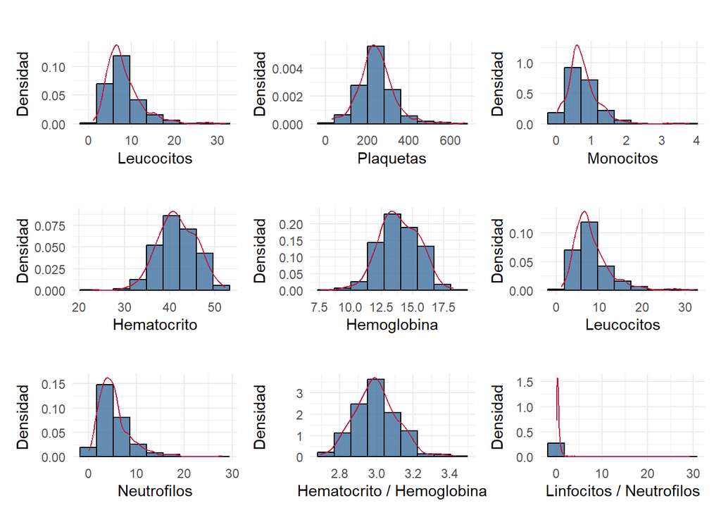

```r
library(GGally)
library(ggplot2)
library(patchwork) #une los graficos en una sola imagen
```

Luego se procede a realizar un histograma por variable pero diviendo el mismo por enfermos y no enfermos

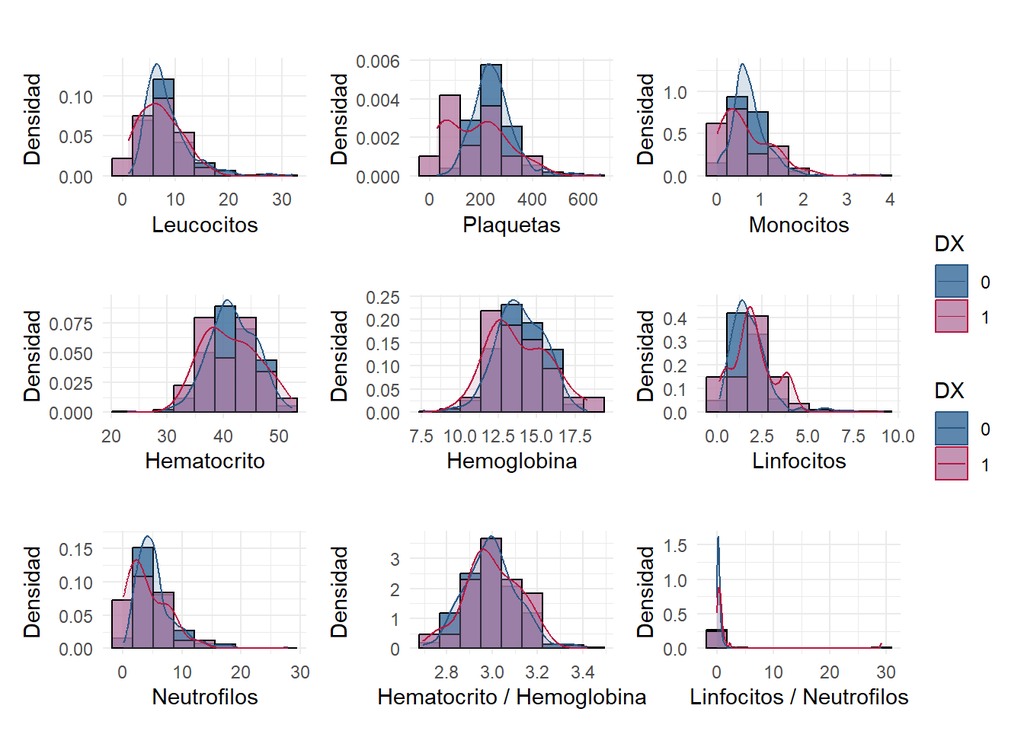

## Boxplot

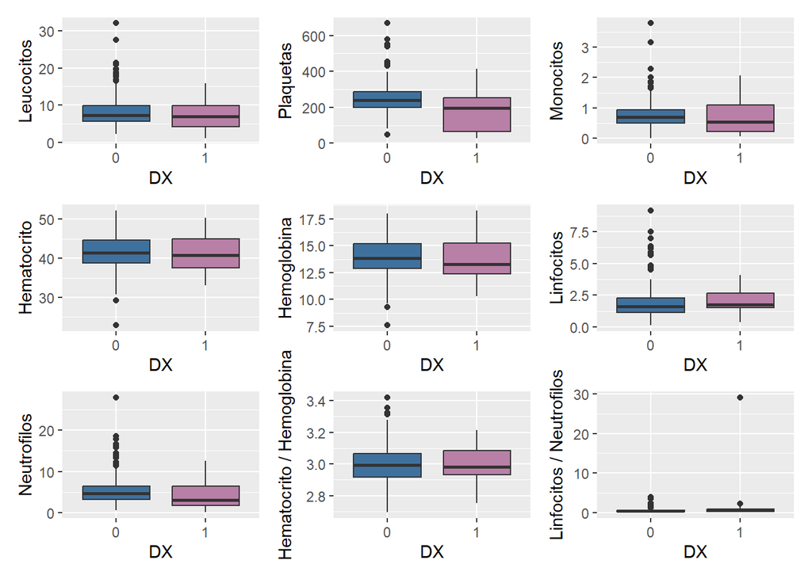

se observan valores atipicos en todas las variables por tanto se procede a analizar dichos valores

## Deteccion de Valores atipicos

```
##  [1]   6   8  71  80 105 106 120 129 155 174 178 211 296 305
```

```r
#Leucocitos
library(knitr)
kable(outLeu, format = "markdown", row.names = FALSE)
```

| Numero | DX | Clasificación Plaquetas | Clasificación Leucositos | Clasificación razón Linf/Neut | Clasificación Hema/Hemog | Clasificación Monocitos | p2-Dolor general | p7-signos de alarma | p1-Malestar general | p5-Erupcion cutanea | p4-Manifestaciones hemorragicas | p8-Ictericia | p6 - presentacion | p3 - sintomas respiratorias | cefalea | escalofrio | hiporexia | odinofagia | salpullido | prurito | vomito (vomito ocasional o persistente) | hepatomegalia | rinorrea | p4 ( manifestaciones hemorragicas) | edemas | p6 (alteracion neurologica) | p9_Leuco | leuco_editada | p10_Plaquetas | … |
| --- | --- | --- | --- | --- | --- | --- | --- | --- | --- | --- | --- | --- | --- | --- | --- | --- | --- | --- | --- | --- | --- | --- | --- | --- | --- | --- | --- | --- | --- | --- |
| 6 | 0 | 0 | 0 | 0 | 0 | 1 | 0 | 0 | 1 | 0 | 0 | 1 | 0 | 0 | 0 | 0 | 1 | 0 | 0 | 0 | 0 | 0 | 1 | 0 | 0 | 0 | 32.11 | 32110 | 578 | … |
| 8 | 0 | 0 | 0 | 0 | 0 | 0 | 0 | 0 | 1 | 0 | 0 | 1 | 0 | 0 | 0 | 0 | 1 | 0 | 0 | 0 | 0 | 0 | 1 | 0 | 0 | 0 | 19.72 | 19720 | 267 | … |
| 71 | 0 | 0 | 0 | 0 | 1 | 0 | 1 | 0 | 0 | 0 | 0 | 1 | 0 | 0 | 1 | 1 | 1 | 1 | 0 | 0 | 1 | 0 | 0 | 0 | 0 | 0 | 18.12 | 18120 | 260 | … |
| 80 | 0 | 0 | 0 | 0 | 1 | 1 | 0 | 1 | 1 | 0 | 0 | 1 | 0 | 0 | 0 | 1 | 1 | 1 | 0 | 0 | 0 | 0 | 1 | 0 | 0 | 0 | 16.54 | 16540 | 257 | … |
| 105 | 0 | 0 | 0 | 0 | 1 | 0 | 0 | 0 | 1 | 0 | 0 | 1 | 0 | 0 | 0 | 1 | 1 | 0 | 0 | 0 | 1 | 0 | 1 | 0 | 1 | 0 | 27.62 | 27620 | 455 | … |
| 106 | 0 | 0 | 0 | 0 | 1 | 1 | 0 | 0 | 1 | 0 | 0 | 1 | 0 | 0 | 0 | 1 | 1 | 0 | 0 | 0 | 1 | 0 | 1 | 0 | 1 | 0 | 27.62 | 27620 | 455 | … |
| 120 | 0 | 0 | 0 | 0 | 0 | 1 | 1 | 0 | 1 | 0 | 0 | 1 | 0 | 0 | 1 | 1 | 1 | 0 | 0 | 0 | 1 | 0 | 1 | 0 | 0 | 0 | 17.70 | 17700 | 338 | … |
| 129 | 0 | 0 | 0 | 0 | 0 | 1 | 1 | 0 | 1 | 0 | 0 | 1 | 0 | 0 | 1 | 1 | 1 | 1 | 0 | 0 | 1 | 0 | 1 | 0 | 0 | 0 | 19.56 | 19560 | 213 | … |
| 155 | 0 | 0 | 0 | 0 | 1 | 1 | 1 | 0 | 1 | 0 | 0 | 1 | 0 | 0 | 1 | 1 | 1 | 1 | 0 | 0 | 0 | 0 | 0 | 0 | 0 | 0 | 16.93 | 16930 | 365 | … |
| 174 | 0 | 0 | 0 | 0 | 1 | 1 | 1 | 0 | 1 | 0 | 0 | 1 | 0 | 0 | 1 | 1 | 1 | 1 | 0 | 0 | 0 | 0 | 1 | 0 | 0 | 0 | 17.96 | 17960 | 317 | … |
| 178 | 0 | 0 | 0 | 0 | 1 | 1 | 1 | 0 | 1 | 0 | 0 | 1 | 0 | 0 | 1 | 1 | 1 | 1 | 0 | 0 | 1 | 0 | 0 | 0 | 0 | 0 | 19.74 | 19740 | 368 | … |
| 211 | 0 | 0 | 0 | 0 | 0 | 1 | 1 | 0 | 1 | 0 | 0 | 1 | 0 | 1 | 1 | 1 | 1 | 0 | 0 | 0 | 0 | 0 | 0 | 0 | 0 | 0 | 20.95 | 20950 | 230 | … |
| 296 | 0 | 0 | 0 | 0 | 1 | 1 | 1 | 0 | 1 | 0 | 0 | 1 | 0 | 1 | 1 | 1 | 0 | 0 | 0 | 0 | 0 | 0 | 0 | 0 | 0 | 0 | 21.40 | 21400 | 276 | … |
| 305 | 0 | 0 | 0 | 0 | 1 | 1 | 1 | 0 | 1 | 0 | 0 | 1 | 1 | 0 | 0 | 1 | 1 | 0 | 0 | 1 | 1 | 0 | 0 | 0 | 0 | 1 | 18.84 | 18840 | 259 | … |

```
##  [1]   6  42 101 105 106 125 166 168 186 297 299 300 309 312 318 319 323
```

```r
#Plaquetas
library(knitr)
kable(outpla, format = "markdown", row.names = FALSE)
```

| Numero | DX | Clasificación Plaquetas | Clasificación Leucositos | Clasificación razón Linf/Neut | Clasificación Hema/Hemog | Clasificación Monocitos | p2-Dolor general | p7-signos de alarma | p1-Malestar general | p5-Erupcion cutanea | p4-Manifestaciones hemorragicas | p8-Ictericia | p6 - presentacion | p3 - sintomas respiratorias | cefalea | escalofrio | hiporexia | odinofagia | salpullido | prurito | vomito (vomito ocasional o persistente) | hepatomegalia | rinorrea | p4 ( manifestaciones hemorragicas) | edemas | p6 (alteracion neurologica) | p9_Leuco | leuco_editada | p10_Plaquetas | … |
| --- | --- | --- | --- | --- | --- | --- | --- | --- | --- | --- | --- | --- | --- | --- | --- | --- | --- | --- | --- | --- | --- | --- | --- | --- | --- | --- | --- | --- | --- | --- |
| 6 | 0 | 0 | 0 | 0 | 0 | 1 | 0 | 0 | 1 | 0 | 0 | 1 | 0 | 0 | 0 | 0 | 1 | 0 | 0 | 0 | 0 | 0 | 1 | 0 | 0 | 0 | 32.11 | 32110 | 578 | … |
| 42 | 0 | 0 | 0 | 1 | 1 | 0 | 1 | 0 | 1 | 0 | 0 | 1 | 0 | 1 | 0 | 0 | 1 | 0 | 0 | 0 | 1 | 0 | 0 | 0 | 0 | 0 | 9.64 | 9640 | 430 | … |
| 101 | 0 | 0 | 0 | 0 | 1 | 0 | 1 | 0 | 1 | 0 | 0 | 1 | 0 | 0 | 1 | 1 | 1 | 0 | 0 | 0 | 0 | 0 | 0 | 0 | 0 | 0 | 9.35 | 9350 | 441 | … |
| 105 | 0 | 0 | 0 | 0 | 1 | 0 | 0 | 0 | 1 | 0 | 0 | 1 | 0 | 0 | 0 | 1 | 1 | 0 | 0 | 0 | 1 | 0 | 1 | 0 | 1 | 0 | 27.62 | 27620 | 455 | … |
| 106 | 0 | 0 | 0 | 0 | 1 | 1 | 0 | 0 | 1 | 0 | 0 | 1 | 0 | 0 | 0 | 1 | 1 | 0 | 0 | 0 | 1 | 0 | 1 | 0 | 1 | 0 | 27.62 | 27620 | 455 | … |
| 125 | 0 | 0 | 0 | 1 | 1 | 0 | 0 | 0 | 1 | 0 | 0 | 1 | 0 | 1 | 0 | 1 | 0 | 0 | 0 | 0 | 1 | 0 | 0 | 0 | 0 | 0 | 11.41 | 11410 | 551 | … |
| 166 | 0 | 0 | 0 | 0 | 1 | 0 | 1 | 0 | 1 | 0 | 0 | 1 | 0 | 0 | 1 | 1 | 0 | 1 | 0 | 0 | 1 | 0 | 1 | 0 | 0 | 0 | 12.50 | 12500 | 668 | … |
| 168 | 0 | 0 | 0 | 0 | 1 | 0 | 1 | 0 | 1 | 0 | 0 | 1 | 0 | 0 | 1 | 1 | 0 | 1 | 0 | 0 | 0 | 0 | 1 | 0 | 0 | 0 | 7.80 | 7800 | 440 | … |
| 186 | 0 | 0 | 0 | 0 | 1 | 1 | 1 | 1 | 1 | 0 | 0 | 1 | 0 | 0 | 1 | 1 | 1 | 1 | 0 | 0 | 1 | 0 | 1 | 0 | 0 | 0 | 14.04 | 14040 | 537 | … |
| 297 | 0 | 0 | 0 | 1 | 0 | 1 | 1 | 0 | 1 | 0 | 0 | 1 | 1 | 0 | 1 | 1 | 1 | 1 | 0 | 0 | 1 | 0 | 1 | 0 | 0 | 1 | 12.48 | 12480 | 447 | … |
| 299 | 1 | 1 | 1 | 1 | 1 | 0 | 1 | 1 | 1 | 0 | 1 | 1 | 0 | 1 | 1 | 1 | 1 | 0 | 0 | 0 | 1 | 1 | 0 | 1 | 0 | 0 | 4.21 | 4210 | 47 | … |
| 300 | 1 | 1 | 1 | 1 | 1 | 0 | 1 | 0 | 1 | 0 | 1 | 1 | 1 | 0 | 1 | 1 | 1 | 0 | 0 | 1 | 1 | 0 | 1 | 1 | 0 | 1 | 3.31 | 3310 | 46 | … |
| 309 | 1 | 1 | 0 | 1 | 1 | 0 | 1 | 0 | 1 | 0 | 0 | 1 | 0 | 1 | 1 | 1 | 1 | 1 | 0 | 0 | 1 | 0 | 0 | 0 | 0 | 0 | 7.00 | 7000 | 36 | … |
| 312 | 1 | 1 | 0 | 0 | 1 | 0 | 1 | 0 | 1 | 1 | 1 | 1 | 1 | 1 | 0 | 0 | 1 | 0 | 1 | 0 | 1 | 0 | 1 | 1 | 0 | 1 | 7.57 | 7570 | 52 | … |
| 318 | 1 | 1 | 1 | 0 | 0 | 0 | 1 | 0 | 1 | 0 | 0 | 1 | 1 | 1 | 1 | 1 | 1 | 0 | 0 | 0 | 1 | 0 | 0 | 0 | 0 | 1 | 1.39 | 1390 | 46 | … |
| 319 | 1 | 1 | 1 | 0 | 1 | 0 | 1 | 0 | 1 | 0 | 0 | 1 | 0 | 0 | 1 | 1 | 1 | 1 | 0 | 0 | 0 | 0 | 0 | 0 | 0 | 0 | 4.38 | 4380 | 29 | … |
| 323 | 0 | 1 | 0 | 0 | 0 | 0 | 1 | 0 | 1 | 0 | 0 | 1 | 0 | 0 | 1 | 1 | 1 | 0 | 0 | 1 | 1 | 0 | 1 | 0 | 0 | 0 | 8.63 | 8630 | 49 | … |

```
##  [1]  75  80 104 106 116 120 181 190 199 213 236 305
```

```r
#Monocitos
library(knitr)
kable(outmono, format = "markdown", row.names = FALSE)
```

| Numero | DX | Clasificación Plaquetas | Clasificación Leucositos | Clasificación razón Linf/Neut | Clasificación Hema/Hemog | Clasificación Monocitos | p2-Dolor general | p7-signos de alarma | p1-Malestar general | p5-Erupcion cutanea | p4-Manifestaciones hemorragicas | p8-Ictericia | p6 - presentacion | p3 - sintomas respiratorias | cefalea | escalofrio | hiporexia | odinofagia | salpullido | prurito | vomito (vomito ocasional o persistente) | hepatomegalia | rinorrea | p4 ( manifestaciones hemorragicas) | edemas | p6 (alteracion neurologica) | p9_Leuco | leuco_editada | p10_Plaquetas | … |
| --- | --- | --- | --- | --- | --- | --- | --- | --- | --- | --- | --- | --- | --- | --- | --- | --- | --- | --- | --- | --- | --- | --- | --- | --- | --- | --- | --- | --- | --- | --- |
| 75 | 1 | 0 | 0 | 0 | 0 | 1 | 1 | 1 | 1 | 0 | 1 | 1 | 1 | 1 | 1 | 1 | 1 | 0 | 0 | 0 | 1 | 0 | 0 | 1 | 0 | 1 | 12.32 | 12320 | 225 | … |
| 80 | 0 | 0 | 0 | 0 | 1 | 1 | 0 | 1 | 1 | 0 | 0 | 1 | 0 | 0 | 0 | 1 | 1 | 1 | 0 | 0 | 0 | 0 | 1 | 0 | 0 | 0 | 16.54 | 16540 | 257 | … |
| 104 | 0 | 0 | 0 | 0 | 1 | 1 | 1 | 0 | 1 | 0 | 0 | 1 | 0 | 1 | 0 | 1 | 1 | 0 | 0 | 0 | 1 | 0 | 0 | 0 | 0 | 0 | 11.11 | 11110 | 301 | … |
| 106 | 0 | 0 | 0 | 0 | 1 | 1 | 0 | 0 | 1 | 0 | 0 | 1 | 0 | 0 | 0 | 1 | 1 | 0 | 0 | 0 | 1 | 0 | 1 | 0 | 1 | 0 | 27.62 | 27620 | 455 | … |
| 116 | 0 | 0 | 0 | 0 | 1 | 1 | 1 | 0 | 1 | 0 | 0 | 1 | 0 | 0 | 1 | 1 | 1 | 1 | 0 | 1 | 1 | 0 | 0 | 0 | 0 | 0 | 13.61 | 13610 | 312 | … |
| 120 | 0 | 0 | 0 | 0 | 0 | 1 | 1 | 0 | 1 | 0 | 0 | 1 | 0 | 0 | 1 | 1 | 1 | 0 | 0 | 0 | 1 | 0 | 1 | 0 | 0 | 0 | 17.70 | 17700 | 338 | … |
| 181 | 0 | 0 | 0 | 0 | 1 | 1 | 1 | 0 | 1 | 0 | 0 | 1 | 0 | 0 | 1 | 1 | 0 | 1 | 0 | 0 | 0 | 0 | 1 | 0 | 0 | 0 | 15.97 | 15970 | 281 | … |
| 190 | 0 | 1 | 0 | 1 | 0 | 1 | 1 | 0 | 1 | 0 | 0 | 1 | 0 | 0 | 1 | 1 | 1 | 0 | 0 | 0 | 0 | 0 | 0 | 0 | 0 | 0 | 12.78 | 12780 | 133 | … |
| 199 | 0 | 0 | 0 | 0 | 1 | 1 | 1 | 0 | 1 | 0 | 1 | 1 | 0 | 1 | 1 | 1 | 0 | 1 | 0 | 0 | 0 | 0 | 0 | 1 | 0 | 0 | 10.96 | 10960 | 192 | … |
| 213 | 0 | 0 | 0 | 0 | 0 | 1 | 1 | 0 | 1 | 0 | 0 | 1 | 0 | 0 | 0 | 0 | 1 | 0 | 0 | 0 | 1 | 0 | 1 | 0 | 0 | 0 | 9.91 | 9910 | 280 | … |
| 236 | 0 | 0 | 0 | 0 | 0 | 1 | 1 | 1 | 1 | 0 | 0 | 1 | 0 | 0 | 1 | 0 | 1 | 1 | 0 | 0 | 1 | 0 | 0 | 0 | 0 | 0 | 15.27 | 15270 | 338 | … |
| 305 | 0 | 0 | 0 | 0 | 1 | 1 | 1 | 0 | 1 | 0 | 0 | 1 | 1 | 0 | 0 | 1 | 1 | 0 | 0 | 1 | 1 | 0 | 0 | 0 | 0 | 1 | 18.84 | 18840 | 259 | … |

```
## [1]  42 124 127 141 186
```

```r
#Hematocrito / Hemoglobina
library(knitr)
kable(outhemahemo, format = "markdown", row.names = FALSE)
```

| Numero | DX | Clasificación Plaquetas | Clasificación Leucositos | Clasificación razón Linf/Neut | Clasificación Hema/Hemog | Clasificación Monocitos | p2-Dolor general | p7-signos de alarma | p1-Malestar general | p5-Erupcion cutanea | p4-Manifestaciones hemorragicas | p8-Ictericia | p6 - presentacion | p3 - sintomas respiratorias | cefalea | escalofrio | hiporexia | odinofagia | salpullido | prurito | vomito (vomito ocasional o persistente) | hepatomegalia | rinorrea | p4 ( manifestaciones hemorragicas) | edemas | p6 (alteracion neurologica) | p9_Leuco | leuco_editada | p10_Plaquetas | … |
| --- | --- | --- | --- | --- | --- | --- | --- | --- | --- | --- | --- | --- | --- | --- | --- | --- | --- | --- | --- | --- | --- | --- | --- | --- | --- | --- | --- | --- | --- | --- |
| 42 | 0 | 0 | 0 | 1 | 1 | 0 | 1 | 0 | 1 | 0 | 0 | 1 | 0 | 1 | 0 | 0 | 1 | 0 | 0 | 0 | 1 | 0 | 0 | 0 | 0 | 0 | 9.64 | 9640 | 430 | … |
| 124 | 0 | 0 | 0 | 0 | 1 | 0 | 1 | 0 | 1 | 0 | 0 | 1 | 0 | 0 | 1 | 1 | 0 | 1 | 0 | 0 | 0 | 0 | 1 | 0 | 0 | 0 | 5.10 | 5100 | 310 | … |
| 127 | 0 | 0 | 0 | 0 | 1 | 0 | 1 | 0 | 1 | 0 | 0 | 1 | 0 | 1 | 1 | 1 | 1 | 0 | 0 | 0 | 1 | 0 | 0 | 0 | 0 | 0 | 7.45 | 7450 | 378 | … |
| 141 | 0 | 0 | 0 | 0 | 1 | 0 | 0 | 0 | 1 | 0 | 0 | 1 | 0 | 0 | 0 | 1 | 1 | 1 | 0 | 0 | 0 | 0 | 0 | 0 | 0 | 0 | 11.32 | 11320 | 384 | … |
| 186 | 0 | 0 | 0 | 0 | 1 | 1 | 1 | 1 | 1 | 0 | 0 | 1 | 0 | 0 | 1 | 1 | 1 | 1 | 0 | 0 | 1 | 0 | 1 | 0 | 0 | 0 | 14.04 | 14040 | 537 | … |

```
##  [1]  10  11  18  30  40  42  60  96 125 196 219 220 227 259 299 300 302 303 320
## [20] 324
```

```r
# Linfocitos / Neutrofilos
library(knitr)
kable(outlineu, format = "markdown", row.names = FALSE)
```

| Numero | DX | Clasificación Plaquetas | Clasificación Leucositos | Clasificación razón Linf/Neut | Clasificación Hema/Hemog | Clasificación Monocitos | p2-Dolor general | p7-signos de alarma | p1-Malestar general | p5-Erupcion cutanea | p4-Manifestaciones hemorragicas | p8-Ictericia | p6 - presentacion | p3 - sintomas respiratorias | cefalea | escalofrio | hiporexia | odinofagia | salpullido | prurito | vomito (vomito ocasional o persistente) | hepatomegalia | rinorrea | p4 ( manifestaciones hemorragicas) | edemas | p6 (alteracion neurologica) | p9_Leuco | leuco_editada | p10_Plaquetas | … |
| --- | --- | --- | --- | --- | --- | --- | --- | --- | --- | --- | --- | --- | --- | --- | --- | --- | --- | --- | --- | --- | --- | --- | --- | --- | --- | --- | --- | --- | --- | --- |
| 10 | 0 | 0 | 0 | 1 | 0 | 0 | 1 | 0 | 1 | 0 | 0 | 1 | 0 | 0 | 1 | 1 | 1 | 1 | 0 | 0 | 1 | 0 | 1 | 0 | 0 | 0 | 5.94 | 5940 | 164 | … |
| 11 | 0 | 1 | 0 | 1 | 0 | 0 | 1 | 0 | 1 | 0 | 0 | 1 | 0 | 0 | 0 | 1 | 1 | 0 | 0 | 0 | 1 | 0 | 0 | 0 | 0 | 0 | 5.07 | 5070 | 134 | … |
| 18 | 0 | 1 | 0 | 1 | 0 | 0 | 0 | 0 | 1 | 1 | 0 | 1 | 0 | 1 | 0 | 0 | 1 | 0 | 1 | 1 | 0 | 0 | 0 | 0 | 0 | 0 | 6.63 | 6630 | 127 | … |
| 30 | 0 | 0 | 0 | 1 | 0 | 0 | 1 | 0 | 1 | 1 | 0 | 1 | 0 | 0 | 1 | 1 | 0 | 0 | 1 | 1 | 0 | 0 | 1 | 0 | 0 | 0 | 9.71 | 9710 | 267 | … |
| 40 | 1 | 0 | 0 | 1 | 0 | 1 | 0 | 0 | 1 | 0 | 0 | 1 | 0 | 1 | 0 | 0 | 1 | 0 | 0 | 0 | 0 | 0 | 0 | 0 | 0 | 0 | 7.40 | 7400 | 391 | … |
| 42 | 0 | 0 | 0 | 1 | 1 | 0 | 1 | 0 | 1 | 0 | 0 | 1 | 0 | 1 | 0 | 0 | 1 | 0 | 0 | 0 | 1 | 0 | 0 | 0 | 0 | 0 | 9.64 | 9640 | 430 | … |
| 60 | 0 | 0 | 0 | 1 | 0 | 0 | 1 | 0 | 1 | 0 | 0 | 1 | 0 | 0 | 1 | 0 | 1 | 1 | 0 | 0 | 0 | 0 | 1 | 0 | 0 | 0 | 7.62 | 7620 | 274 | … |
| 96 | 0 | 0 | 0 | 1 | 0 | 0 | 1 | 0 | 1 | 0 | 0 | 1 | 0 | 0 | 1 | 1 | 1 | 0 | 0 | 0 | 0 | 0 | 1 | 0 | 0 | 0 | 4.84 | 4840 | 225 | … |
| 125 | 0 | 0 | 0 | 1 | 1 | 0 | 0 | 0 | 1 | 0 | 0 | 1 | 0 | 1 | 0 | 1 | 0 | 0 | 0 | 0 | 1 | 0 | 0 | 0 | 0 | 0 | 11.41 | 11410 | 551 | … |
| 196 | 0 | 0 | 1 | 1 | 0 | 0 | 1 | 0 | 1 | 0 | 0 | 1 | 0 | 1 | 1 | 1 | 1 | 1 | 0 | 0 | 0 | 0 | 1 | 0 | 0 | 0 | 3.09 | 3090 | 194 | … |
| 219 | 0 | 0 | 1 | 1 | 1 | 0 | 1 | 0 | 1 | 0 | 0 | 1 | 0 | 1 | 1 | 1 | 0 | 0 | 0 | 0 | 1 | 0 | 0 | 0 | 0 | 0 | 4.02 | 4020 | 268 | … |
| 220 | 0 | 0 | 1 | 1 | 0 | 0 | 1 | 0 | 1 | 0 | 0 | 1 | 0 | 1 | 1 | 1 | 1 | 0 | 0 | 0 | 0 | 0 | 0 | 0 | 0 | 0 | 4.49 | 4490 | 193 | … |
| 227 | 0 | 0 | 1 | 1 | 0 | 0 | 0 | 0 | 0 | 0 | 0 | 1 | 0 | 1 | 0 | 0 | 0 | 0 | 0 | 0 | 0 | 0 | 0 | 0 | 0 | 0 | 3.85 | 3850 | 191 | … |
| 259 | 0 | 0 | 0 | 1 | 0 | 0 | 1 | 0 | 1 | 0 | 0 | 1 | 0 | 1 | 1 | 1 | 0 | 0 | 0 | 0 | 0 | 0 | 0 | 0 | 0 | 0 | 4.91 | 4910 | 195 | … |
| 299 | 1 | 1 | 1 | 1 | 1 | 0 | 1 | 1 | 1 | 0 | 1 | 1 | 0 | 1 | 1 | 1 | 1 | 0 | 0 | 0 | 1 | 1 | 0 | 1 | 0 | 0 | 4.21 | 4210 | 47 | … |
| 300 | 1 | 1 | 1 | 1 | 1 | 0 | 1 | 0 | 1 | 0 | 1 | 1 | 1 | 0 | 1 | 1 | 1 | 0 | 0 | 1 | 1 | 0 | 1 | 1 | 0 | 1 | 3.31 | 3310 | 46 | … |
| 302 | 0 | 0 | 0 | 1 | 0 | 0 | 1 | 0 | 1 | 0 | 0 | 1 | 0 | 0 | 1 | 1 | 1 | 0 | 0 | 0 | 1 | 0 | 0 | 0 | 0 | 0 | 8.10 | 8100 | 176 | … |
| 303 | 0 | 0 | 0 | 1 | 0 | 1 | 0 | 0 | 1 | 1 | 0 | 1 | 0 | 0 | 0 | 1 | 1 | 0 | 1 | 0 | 1 | 0 | 1 | 0 | 0 | 0 | 8.37 | 8370 | 241 | … |
| 320 | 0 | 0 | 0 | 1 | 1 | 0 | 1 | 1 | 1 | 0 | 1 | 1 | 0 | 0 | 1 | 1 | 1 | 1 | 0 | 1 | 1 | 0 | 1 | 1 | 0 | 0 | 16.10 | 16100 | 304 | … |
| 324 | 1 | 1 | 0 | 1 | 0 | 0 | 1 | 0 | 1 | 1 | 0 | 1 | 0 | 0 | 1 | 1 | 1 | 1 | 1 | 1 | 1 | 0 | 0 | 0 | 0 | 0 | 6.90 | 6900 | 84 | … |

## Matrix de correlacion de Pearson

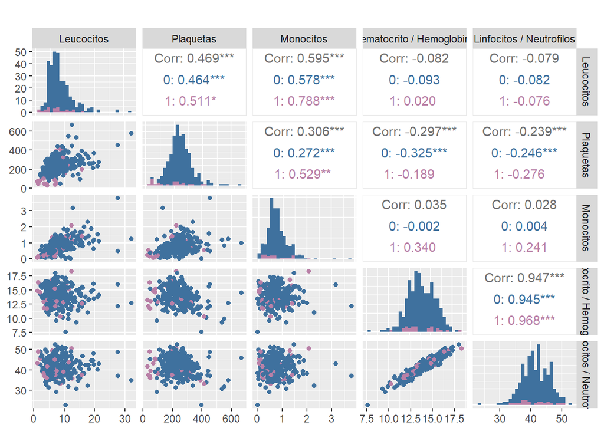